# Fruits

Pablo Dominguez

2022-04-22

```r
library(readxl)
library(dplyr)
library(knitr)
library(ggplot2)
library(ggpubr)
library(pastecs)
```

# Entrega MACE bloque 2

## Introducción

Por su riqueza en proteínas, carbohidratos, lípidos y minerales las semillas de calabaza son un producto que llega a ser consumido a lo largo de países en todo el mundo. Los factores que determinan el tipo concreto de cada semilla son generalmente relativos a la apariencia externa de la misma. Distinguir el tipo de cada semilla suele requerir experiencia y tiempo, cosa que en nuestro mundo moderno se traduce como un coste económico.

Con el objetivo de aportar una nueva manera de realizar esta tarea, nos proponemos plantear un algoritmo de clasificación binaria tipo `SVM` que, a partir de la base de datos `Pumpkin_Seeds_Dataset.xlsx`, distinga entre dos categorías diferentes de semillas de calabaza.

Así pues, comenzaremos este estudio con un análisis exploratorio de los datos, para seguir con una construcción de un clasificador a partir de este algoritmo y acabar con una evaluación de los diferentes resultados obtenidos.

## Base de datos

### Presentación de los datos

Tal y como se muestra a continuación, tenemos las dos categorías balanceadas de semillas de calabaza *Çerçevelik* y *Ürgüp Sivrisi*:

```r
df <- readxl::read_excel("../Pumpkin_Seeds_Dataset/Pumpkin_Seeds_Dataset.xlsx")
table(df$Class)
```

```
##
##    Çerçevelik Ürgüp Sivrisi
##          1300          1200
```

> Citation Request : KOKLU, M., SARIGIL, S., & OZBEK, O. (2021). The use of machine learning methods in classification of pumpkin seeds (Cucurbita pepo L.). Genetic Resources and Crop Evolution, 68(7), 2713-2726. Doi: https://doi.org/10.1007/s10722-021-01226-0

> Puedes conseguir la base de datos en [este enlace](https://www.muratkoklu.com/datasets/Pumpkin_Seeds_Dataset.zip).

### Variables a considerar

En el caso de nuestro estudio, salvo que alguna de las variables tenga poca calidad de dato e introduzca ruido, conservaremos todas para que el modelo disponga de la mayor cantidad de información. El significado de las variables de las que disponemos es por lo general evidente a partir del nombre de la misma. Mostramos a continuación la lista de variables que se han medido para cada muestra, así como el tipo de cada variable en nuestra base de datos:

```r
df %>% sapply(class) %>% kable(.,col.names = c("Tipo"))
```

|  | Tipo |
| --- | --- |
| Area | numeric |
| Perimeter | numeric |
| Major_Axis_Length | numeric |
| Minor_Axis_Length | numeric |
| Convex_Area | numeric |
| Equiv_Diameter | numeric |
| Eccentricity | numeric |
| Solidity | numeric |
| Extent | numeric |
| Roundness | numeric |
| Aspect_Ration | numeric |
| Compactness | numeric |
| Class | character |

### Calidad del dato

En cuanto a los valores faltantes, tenemos la siguiente información:

```r
for(col in df %>% colnames()){
  print(paste0("Hay ",df[col] %>% is.na() %>% sum()," valores faltantes y ",df[col] %>% is.null() %>% sum()," valores nulos en la columna ",col))
}
```

```
## [1] "Hay 0 valores faltantes y 0 valores nulos en la columna Area"
## [1] "Hay 0 valores faltantes y 0 valores nulos en la columna Perimeter"
## [1] "Hay 0 valores faltantes y 0 valores nulos en la columna Major_Axis_Length"
## [1] "Hay 0 valores faltantes y 0 valores nulos en la columna Minor_Axis_Length"
## [1] "Hay 0 valores faltantes y 0 valores nulos en la columna Convex_Area"
## [1] "Hay 0 valores faltantes y 0 valores nulos en la columna Equiv_Diameter"
## [1] "Hay 0 valores faltantes y 0 valores nulos en la columna Eccentricity"
## [1] "Hay 0 valores faltantes y 0 valores nulos en la columna Solidity"
## [1] "Hay 0 valores faltantes y 0 valores nulos en la columna Extent"
## [1] "Hay 0 valores faltantes y 0 valores nulos en la columna Roundness"
## [1] "Hay 0 valores faltantes y 0 valores nulos en la columna Aspect_Ration"
## [1] "Hay 0 valores faltantes y 0 valores nulos en la columna Compactness"
## [1] "Hay 0 valores faltantes y 0 valores nulos en la columna Class"
```

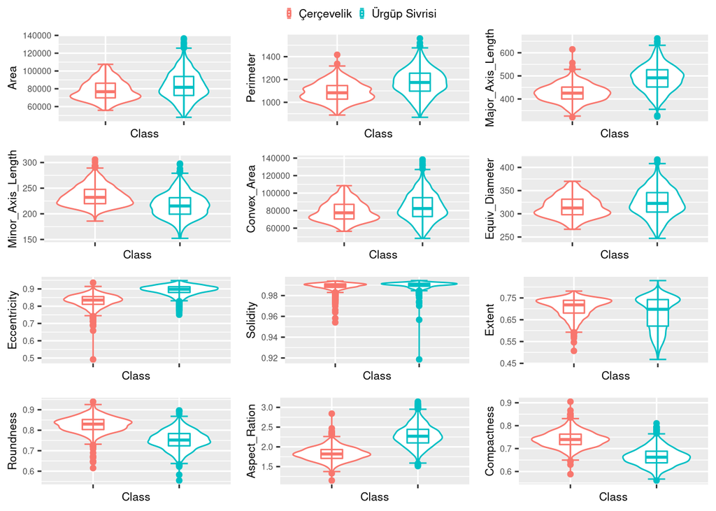

```r
ps <- list()
for(colu in df %>% colnames() %>% setdiff(.,"Class")){
  p <- ggplot(df, aes_string(x="Class", y=colu, color="Class")) + geom_violin() + geom_boxplot(width=0.25) + stat_boxplot(geom = "errorbar", width = 0.2) + theme(
    axis.text.x = element_blank(),
    axis.text.y = element_text(size=6),
    axis.title.x = element_text(size = 8),
    axis.title.y = element_text(size = 8),
    legend.key.size = unit(0.1, 'cm'),
    legend.text = element_text(size=8),
    legend.title = element_blank())
  ps[[colu]] <- p
}
ggarrange(plotlist =  ps, nrow = 4,ncol = 3,common.legend = TRUE)
```

```r
# Poner nombre primeras columnas (footnote)
col_numeric <- which( sapply(df, is.numeric ) )   # Seleccionamos solamente las columnas numéricas.
quantile_df <- sapply(col_numeric, function( y ) {
                      quantile( x = unlist( df[,  y ] ), c(.25,.5,.75))
                      }) %>% as.data.frame()
rownames(quantile_df) <- c("Q1","Q2","Q3")

stat.desc(df[,1:floor(ncol(df)/2)]) %>% slice(., 4:ncol(df)) %>% bind_rows(.,quantile_df[,1:floor(ncol(df)/2)]) %>% kable(., format = "markdown")
```

|  | Area | Perimeter | Major_Axis_Length | Minor_Axis_Length | Convex_Area | Equiv_Diameter |
| --- | --- | --- | --- | --- | --- | --- |
| min | 4.793900e+04 | 8.684850e+02 | 3.208446e+02 | 1.521718e+02 | 4.836600e+04 | 2.470584e+02 |
| max | 1.365740e+05 | 1.559450e+03 | 6.619113e+02 | 3.058180e+02 | 1.383840e+05 | 4.170029e+02 |
| range | 8.863500e+04 | 6.909650e+02 | 3.410667e+02 | 1.536462e+02 | 9.001800e+04 | 1.699445e+02 |
| sum | 2.016456e+08 | 2.825698e+06 | 1.141505e+06 | 5.644873e+05 | 2.037702e+08 | 7.983356e+05 |
| median | 7.907600e+04 | 1.123672e+03 | 4.494966e+02 | 2.247031e+02 | 7.987200e+04 | 3.173053e+02 |
| mean | 8.065822e+04 | 1.130279e+03 | 4.566018e+02 | 2.257949e+02 | 8.150808e+04 | 3.193342e+02 |
| SE.mean | 2.732902e+02 | 2.185128e+00 | 1.124714e+00 | 4.659449e-01 | 2.752819e+02 | 5.378384e-01 |
| CI.mean.0.95 | 5.358985e+02 | 4.284848e+00 | 2.205467e+00 | 9.136777e-01 | 5.398040e+02 | 1.054655e+00 |
| var | 1.867188e+08 | 1.193696e+04 | 3.162454e+03 | 5.427616e+02 | 1.894503e+08 | 7.231753e+02 |
| std.dev | 1.366451e+04 | 1.092564e+02 | 5.623570e+01 | 2.329724e+01 | 1.376409e+04 | 2.689192e+01 |
| Q1 | 7.076500e+04 | 1.048830e+03 | 4.149579e+02 | 2.112459e+02 | 7.151200e+04 | 3.001680e+02 |
| Q2 | 7.907600e+04 | 1.123672e+03 | 4.494966e+02 | 2.247031e+02 | 7.987200e+04 | 3.173053e+02 |
| Q3 | 8.975750e+04 | 1.203341e+03 | 4.927376e+02 | 2.406729e+02 | 9.079775e+04 | 3.380574e+02 |